# Health Survey Data Analysis of BMI

Bilsay Varcin

March 30, 2020

## Survey of BMI and physical activity

We’ve all taken a survey at some point, but do you ever wonder what happens to your answers? Surveys are given to a carefully selected sample of people with the goal of generalizing the results to a much larger population.

The [National Health and Nutrition Examination Survey (NHANES)](https://www.cdc.gov/nchs/nhanes/index.htm) data is a complex survey of tens of thousands of people designed to assess the health and nutritional status of adults and children in the United States. The NHANES data includes many measurements related to overall health, physical activity, diet, psychological health, socioeconomic factors and more.

Depending on the sampling design, each person has a sampling weight that quantifies how many people in the larger population their data is meant to represent. In this notebook, we’ll apply survey methods that use sampling weights to estimate and model relationships between measurements.

We are going to focus on a common health indicator, Body Mass Index ([BMI](https://en.wikipedia.org/wiki/Body_mass_index) kg/m2), and how it is related to physical activity. We’ll visualize the data and use survey-weighted regression to test for associations.

```
## Observations: 20,293
## Variables: 78
## $ ID               <int> 51624, 51625, 51626, 51627, 51628, 51629, 51630, 5...
## $ SurveyYr         <fct> 2009_10, 2009_10, 2009_10, 2009_10, 2009_10, 2009_...
## $ Gender           <fct> male, male, male, male, female, male, female, fema...
## $ Age              <int> 34, 4, 16, 10, 60, 26, 49, 1, 10, 80, 10, 80, 4, 3...
## $ AgeMonths        <int> 409, 49, 202, 131, 722, 313, 596, 12, 124, NA, 121...
## $ Race1            <fct> White, Other, Black, Black, Black, Mexican, White,...
## $ Race3            <fct> NA, NA, NA, NA, NA, NA, NA, NA, NA, NA, NA, NA, NA...
## $ Education        <fct> High School, NA, NA, NA, High School, 9 - 11th Gra...
## $ MaritalStatus    <fct> Married, NA, NA, NA, Widowed, Married, LivePartner...
## $ HHIncome         <fct> 25000-34999, 20000-24999, 45000-54999, 20000-24999...
## $ HHIncomeMid      <int> 30000, 22500, 50000, 22500, 12500, 30000, 40000, 4...
## $ Poverty          <dbl> 1.36, 1.07, 2.27, 0.81, 0.69, 1.01, 1.91, 1.36, 2....
## $ HomeRooms        <int> 6, 9, 5, 6, 6, 4, 5, 5, 7, 4, 5, 5, 7, NA, 6, 6, 5...
```

[output cut: 65 more lines]

## Visualize survey weight and strata variables

We see from glimpse() that the NHANESraw data has many health measurement variables. It also contains a sampling weight variable WTMEC2YR.

Since NHANESraw data spans 4 years (2009-2012) and the sampling weights are based on 2 years of data, we first need to create a weight variable that scales the sample across the full 4 years. Currently the weights sum to 2 times the US population number, so we need to divide the 2-year weight in half so that in total, the sum of the weights is equal to the US population.

The NHANES data has oversampled some geographic regions and specific minority groups. By examining the distribution of sampling weights for each race, we can see that Whites are undersampled and have higher weights while oversampled Black, Mexican, Hispanic people have lower weights since each sampled person in these minority groups represents fewer US people.

```
## [1] 304267200
```

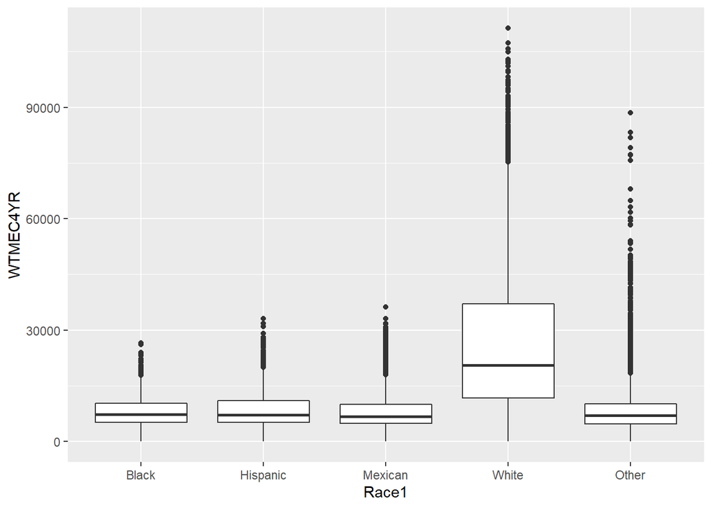

## Specify the survey design

We will now use the survey package to specify the complex survey design that we will use in later analyses. We need to specify the design so the sampling weights and design are used properly in the statistical models.

The NHANESraw data contains a strata variable SDMVSTRA, and a cluster id variable (also known as a primary sampling unit, PSU), SDMVPSU, that accounts for design effects of clustering. These clusters (PSUs) are nested within strata.

```
## Stratified 1 - level Cluster Sampling design (with replacement)
## With (62) clusters.
## svydesign(data = NHANESraw, strata = ~SDMVSTRA, id = ~SDMVPSU,
##     nest = T, weights = ~WTMEC4YR)
## Probabilities:
##      Min.   1st Qu.    Median      Mean   3rd Qu.      Max.
## 8.986e-06 5.664e-05 1.054e-04       Inf 1.721e-04       Inf
## Stratum Sizes:
##             75  76  77  78  79  80  81  82  83  84  85  86  87  88  89  90  91
## obs        803 785 823 829 696 751 696 724 713 683 592 946 598 647 251 862 998
## design.PSU   2   2   2   2   2   2   2   2   2   2   2   3   2   2   2   3   3
## actual.PSU   2   2   2   2   2   2   2   2   2   2   2   3   2   2   2   3   3
##             92  93  94  95  96  97  98  99 100 101 102 103
## obs        875 602 688 722 676 608 708 682 700 715 624 296
## design.PSU   3   2   2   2   2   2   2   2   2   2   2   2
## actual.PSU   3   2   2   2   2   2   2   2   2   2   2   2
## Data variables:
##  [1] "ID"               "SurveyYr"         "Gender"           "Age"
##  [5] "AgeMonths"        "Race1"            "Race3"            "Education"
##  [9] "MaritalStatus"    "HHIncome"         "HHIncomeMid"      "Poverty"
## [13] "HomeRooms"        "HomeOwn"          "Work"             "Weight"
## [17] "Length"           "HeadCirc"         "Height"           "BMI"
## [21] "BMICatUnder20yrs" "BMI_WHO"          "Pulse"            "BPSysAve"
## [25] "BPDiaAve"         "BPSys1"           "BPDia1"           "BPSys2"
## [29] "BPDia2"           "BPSys3"           "BPDia3"           "Testosterone"
## [33] "DirectChol"       "TotChol"          "UrineVol1"        "UrineFlow1"
## [37] "UrineVol2"        "UrineFlow2"       "Diabetes"         "DiabetesAge"
## [41] "HealthGen"        "DaysPhysHlthBad"  "DaysMentHlthBad"  "LittleInterest"
## [45] "Depressed"        "nPregnancies"     "nBabies"          "Age1stBaby"
## [49] "SleepHrsNight"    "SleepTrouble"     "PhysActive"       "PhysActiveDays"
## [53] "TVHrsDay"         "CompHrsDay"       "TVHrsDayChild"    "CompHrsDayChild"
## [57] "Alcohol12PlusYr"  "AlcoholDay"       "AlcoholYear"      "SmokeNow"
## [61] "Smoke100"         "SmokeAge"         "Marijuana"        "AgeFirstMarij"
## [65] "RegularMarij"     "AgeRegMarij"      "HardDrugs"        "SexEver"
## [69] "SexAge"           "SexNumPartnLife"  "SexNumPartYear"   "SameSex"
## [73] "SexOrientation"   "WTINT2YR"         "WTMEC2YR"         "SDMVPSU"
## [77] "SDMVSTRA"         "PregnantNow"      "WTMEC4YR"
```

## Subset the data

Analysis of survey data requires careful consideration of the sampling design and weights at every step. Something as simple as filtering the data becomes complicated when weights are involved.

When we wish to examine a subset of the data (i.e. the subpopulation of adult Hispanics with diabetes, or pregnant women), we must explicitly specify this in the design. We cannot simply remove that subset of the data through filtering the raw data because the survey weights will no longer be correct and will not add up to the full US population.

BMI categories are different for children and young adults younger than 20 so we will subset the data to only analyze adults of at least 20 years of age.

```
## Stratified 1 - level Cluster Sampling design (with replacement)
## With (62) clusters.
## subset(nhanes_design, Age >= 20)
## Probabilities:
##      Min.   1st Qu.    Median      Mean   3rd Qu.      Max.
## 8.986e-06 4.303e-05 8.107e-05       Inf 1.240e-04       Inf
## Stratum Sizes:
##             75  76  77  78  79  80  81  82  83  84  85  86  87  88  89  90  91
## obs        471 490 526 500 410 464 447 400 411 395 357 512 327 355 153 509 560
## design.PSU   2   2   2   2   2   2   2   2   2   2   2   3   2   2   2   3   3
## actual.PSU   2   2   2   2   2   2   2   2   2   2   2   3   2   2   2   3   3
##             92  93  94  95  96  97  98  99 100 101 102 103
## obs        483 376 368 454 362 315 414 409 377 460 308 165
## design.PSU   3   2   2   2   2   2   2   2   2   2   2   2
## actual.PSU   3   2   2   2   2   2   2   2   2   2   2   2
## Data variables:
##  [1] "ID"               "SurveyYr"         "Gender"           "Age"
##  [5] "AgeMonths"        "Race1"            "Race3"            "Education"
##  [9] "MaritalStatus"    "HHIncome"         "HHIncomeMid"      "Poverty"
## [13] "HomeRooms"        "HomeOwn"          "Work"             "Weight"
## [17] "Length"           "HeadCirc"         "Height"           "BMI"
## [21] "BMICatUnder20yrs" "BMI_WHO"          "Pulse"            "BPSysAve"
## [25] "BPDiaAve"         "BPSys1"           "BPDia1"           "BPSys2"
## [29] "BPDia2"           "BPSys3"           "BPDia3"           "Testosterone"
## [33] "DirectChol"       "TotChol"          "UrineVol1"        "UrineFlow1"
## [37] "UrineVol2"        "UrineFlow2"       "Diabetes"         "DiabetesAge"
## [41] "HealthGen"        "DaysPhysHlthBad"  "DaysMentHlthBad"  "LittleInterest"
## [45] "Depressed"        "nPregnancies"     "nBabies"          "Age1stBaby"
## [49] "SleepHrsNight"    "SleepTrouble"     "PhysActive"       "PhysActiveDays"
## [53] "TVHrsDay"         "CompHrsDay"       "TVHrsDayChild"    "CompHrsDayChild"
## [57] "Alcohol12PlusYr"  "AlcoholDay"       "AlcoholYear"      "SmokeNow"
## [61] "Smoke100"         "SmokeAge"         "Marijuana"        "AgeFirstMarij"
## [65] "RegularMarij"     "AgeRegMarij"      "HardDrugs"        "SexEver"
## [69] "SexAge"           "SexNumPartnLife"  "SexNumPartYear"   "SameSex"
## [73] "SexOrientation"   "WTINT2YR"         "WTMEC2YR"         "SDMVPSU"
## [77] "SDMVSTRA"         "PregnantNow"      "WTMEC4YR"
```

```
## [1] 20293
```

```
## [1] 11778
```

## Visualizing BMI

We let svydesign() do its magic, but how does this help us learn about the full US population? With survey methods, we can use the sampling weights to estimate the true distributions of measurements within the entire population. This works for many statistics such as means, proportions, and standard deviations.

We’ll use survey methods to estimate average BMI in the US adult population and also to draw a weighted histogram of the distribution.

```
## # A tibble: 1 x 1
##   `mean(BMI, na.rm = TRUE)`
##                       <dbl>
## 1                      29.0
```

```
##       mean     SE
## BMI 28.734 0.1235
```

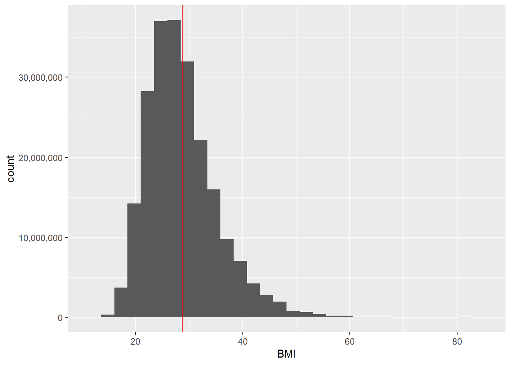

## Is BMI lower in physically active people?

The distribution of BMI looks to be about what we might expect with most people under 40 kg/m2 and a slight positive skewness because a few people have much higher BMI. Now to the question of interest: does the distribution of BMI differ between people who are physically active versus those who are not physically active? We can visually compare BMI with a boxplot as well as formally test for a difference in mean BMI.

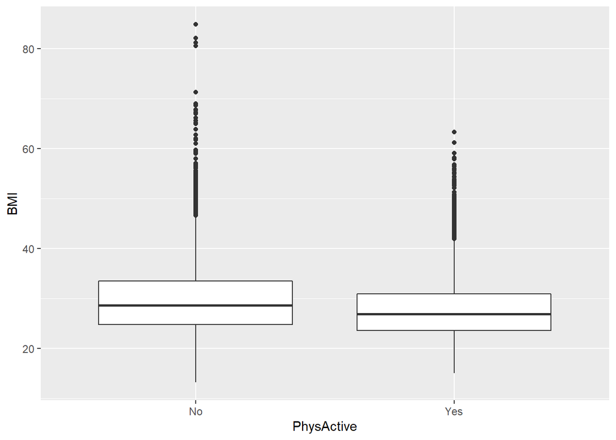

```
## # A tibble: 1 x 8
##   estimate statistic  p.value parameter conf.low conf.high method    alternative
##      <dbl>     <dbl>    <dbl>     <dbl>    <dbl>     <dbl> <chr>     <chr>
## 1    -1.85     -9.72 4.56e-11        32    -2.22     -1.47 Design-b~ two.sided
```

## Could there be confounding by smoking? (part 1)

The relationship between physical activity and BMI is likely not so simple as “if you exercise you will lower your BMI.” In fact, many other lifestyle or demographic variables could be confounding this relationship. One such variable could be smoking status. If someone smokes, is he or she more or less likely to be physically active? Are smokers more likely to have higher or lower BMI? We can examine these relationships in the survey data. Note that many people chose not to answer the smoking question, so we reduce our sample size when looking at this data.

First, let’s look at the relationship between smoking and physical activity.

```
##   SmokeNow PhysActiveNo PhysActiveYes se.PhysActiveNo se.PhysActiveYes
## 1       No    0.4566990     0.5433010      0.01738054       0.01738054
## 2      Yes    0.5885421     0.4114579      0.01163246       0.01163246
```

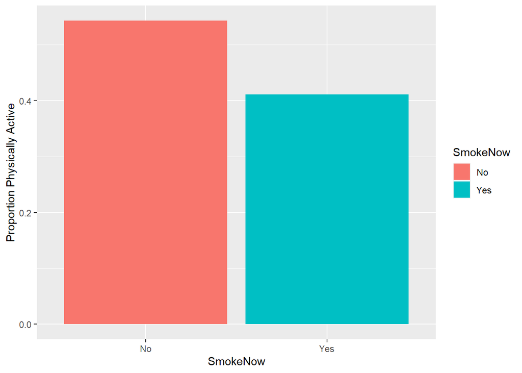

## Could there be confounding by smoking? (part 2)

Now let’s examine the relationship between smoking with BMI.

```
##     SmokeNow      BMI        se
## No        No 29.25734 0.1915138
## Yes      Yes 27.74873 0.1652377
```

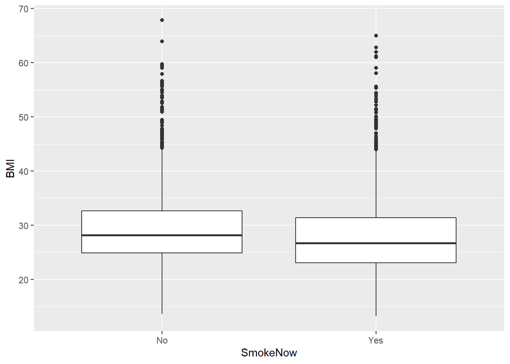

## Add smoking in the mix

We saw that people who smoke are less likely to be physically active and have a lower BMI on average. We also saw that people who are not physically active have a higher BMI on average. How do these seemingly conflicting associations work together? To get a better sense of what’s going on, we can compare BMI by physical activity stratified by smoking status.

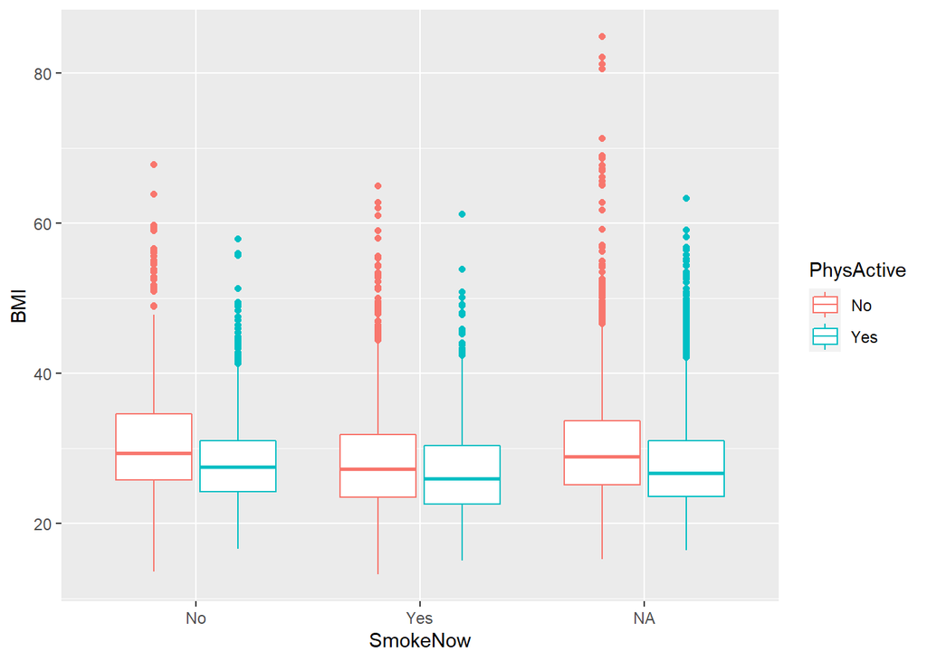

## Incorporate possible confounding in the model

In the above plot, we see that people who are physically active tend to have lower BMI no matter their smoking status, and this is true even if they didn’t answer the question. However, we also see that smokers have lower BMI in general. Also, looking closely we see the difference in BMI comparing physically active people to non-physically active people is slightly smaller in smokers than in non-smokers.

Previously, we used a simple t-test to compare mean BMI in physically active people and non-physically active people. In order to adjust for smoking status, as well as other possible confounders or predictors of BMI, we can use a linear regression model with multiple independent variables. When using survey data, we use a weighted linear regression method which is a special case of generalized linear models (GLMs).

```
## # A tibble: 4 x 5
##   term                      estimate std.error statistic  p.value
##   <chr>                        <dbl>     <dbl>     <dbl>    <dbl>
## 1 (Intercept)                  30.5      0.210    146.   2.62e-44
## 2 SmokeNowYes                  -2.24     0.267     -8.40 2.26e- 9
## 3 PhysActiveYes                -2.35     0.236     -9.97 4.96e-11
## 4 SmokeNowYes:PhysActiveYes     1.00     0.344      2.92 6.52e- 3
```

## What does it all mean?

We fit a linear regression model where the association of physical activity with BMI could vary by smoking status. The interaction between physical activity and smoking has a small p-value, which suggests the association does vary by smoking status. The difference between physically active and non-physically active people is larger in magnitude in the non-smoker population.

We should check the model fit and technical assumptions of our regression model. Then, we can conclude that physically active people tend to have lower BMI, as do smokers. Although they have similar effect sizes, we probably wouldn’t want to recommend smoking along with exercise!

In order to determine whether physical activity causes lower BMI, we would need to use causal inference methods or a randomized control study. We can adjust for other possible confounders in our regression model to determine if physical activity is still associated with BMI, but we fall short of confirming that physical activity itself can lower one’s BMI.

```
## # A tibble: 10 x 5
##    term                      estimate std.error statistic  p.value
##    <chr>                        <dbl>     <dbl>     <dbl>    <dbl>
##  1 (Intercept)                 33.2       0.316   105.    1.75e-33
##  2 PhysActiveYes               -2.11      0.273    -7.75  5.56e- 8
##  3 SmokeNowYes                 -2.23      0.303    -7.34  1.40e- 7
##  4 Race1Hispanic               -1.47      0.420    -3.49  1.88e- 3
##  5 Race1Mexican                -0.191     0.464    -0.412 6.84e- 1
##  6 Race1White                  -2.08      0.320    -6.49  1.04e- 6
##  7 Race1Other                  -3.11      0.620    -5.01  4.09e- 5
##  8 Alcohol12PlusYrYes          -0.855     0.358    -2.39  2.50e- 2
##  9 Gendermale                  -0.256     0.230    -1.11  2.78e- 1
## 10 PhysActiveYes:SmokeNowYes    0.737     0.387     1.90  6.92e- 2
```